# Machine Learning for Acoustics Summer School 2019

## - UKAN Network, Gregynog Hall, Wales (UK) -

#### Summary of Challenge

This is my solution to the final challenge that was proposed at the end the one week long Machine Learning for Acoustics Summer School organized by UKAN Network in Gregynog Hall https://acoustics.ac.uk/early-careers-group/acoustics-network-summer-school-2019/. Although I didn't get the right answer at the end of the challenge, my team and I were pretty close..if we just had 5 more minutes!! Luckily foosball was there to channel our frustration. Anyway, the train journey back to Scotland was long enough (and slowed down by bad weather) to have time to fix the code and polish it. Here's a summary of the challenge and below you can find the full solution.

#### Goal of the challenge:

The goal of the challenge was to apply machine learning techinques learned during the week to a problem in acoustics. Specifically, this was a problem related to NDT (non destructive testing) of a composite plate. NDT uses ultrasounds to detect cracks or damages in structures such as a bridge, a building, a composite plate. A change in the response to ultrasounds can raise an alarm on the state of the structure. A training set was first given to the participants to obtain a model of the undamaged plate. After a couple of hours, a validation data set was provided to test the validity of the model. Finally, during the last our of the challenge, an evaluation data set was sent to the participants. This evaluation data set consisted just of 50 points and the aim of the challenge was to predict how many -and possibly which- of these points were damaged.

#### Techiques used:

Unsupervised Learning, Features Extraction, Fast Fourier Transform, Density Estimation, Radial Basis Function Kernel, Nonlinear Regression, Classification

#### Language:

Python.

A crash course on Python for Data Science was provided during the week. Main libraries used: Numpy, Scipy, Matplotlib, Panda. The machine learning techniques were coded by hand, in order to better understand the theory, hence no machine learning libraries were used.

#### Output:

[figure not shown]

[figure not shown]

A 2D RBF kernel density distribution can provide a better model to identify the system. The two features plotted in these two graphs are resoance frequency and maximum amplitude at resonance. On the left, the training points are plotted on top of their calculated distribution. On the right, the evaluation set is plotted on top of the training points density distribution. It is already evident that many of the evaluation data are abnormal, but it is hard to quantify how many. So for now an estimate can be given by visual inspection.

[figure not shown]

# Final Challenge - Full Solution

We want to create a machine learning model that is capable of detecting whether a recorded ultrasound signal in a structure is indicative of damage or any other change in the structure.

Experiment Information:

Challenge steps:

- 1) Training: You will load and visualise the training data, extract features from it and train and cross-validate a model
- 2) Validation: You will be given more data to validate your trained model
- 3) Evaluation: We will "place" a small number of sensors on known locations, and evauate a set of waveforms and decide whether an alarm should be raised or not

## Step 1: Loading the Data

Before doing anything else, I wanted to load the data and have a quick look at them, to see what is the dimension of the data set and how the points are spatially distributed.

```python
## Import Libraries
from scipy.io import loadmat, savemat
import numpy as np
import matplotlib.pyplot as plt

## Load data
data_train = loadmat('ML_challenge_wave_data_training.mat')

# nxd matrix, n: num of ultrasonic pulses collected, d: num of data points in each wave
X_train = data_train['wave']
# nx3 matrix, n: num of observations along the rows and , x,y,z coordinates along the columns
xyz_train = data_train['xyz']
```

```
The matrix X has dimensions:  (2726, 2048)
The matrix xyz has dimensions:  (2726, 3)
This means that the training data set has 2726 points

By plotting the coordinated of the training points we can see that they are uniformly distributed along the plate
```

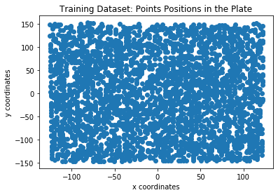

```python
## Let's look at the data
print('The matrix X has dimensions: ',np.shape(X_train))
print('The matrix xyz has dimensions: ',np.shape(xyz_train))
print('This means that the training data set has 2726 points')

# How the points are placed in the plate
plt.figure()
plt.plot(xyz_train[:,0], xyz_train[:,1], 'o')
plt.title('Training Dataset: Points Positions in the Plate')
plt.xlabel('x coordinates')
plt.ylabel('y coordinates')
print('')
print('By plotting the coordinated of the training points we can see that they are uniformly distributed along the plate')
```

## Step 2: Features Extraction

Then I started to plot some features that could give some insight on the data. For example, the main features I looked at for each point were:

- the maximum absolute amplitude of vibration
- the rms
- the frequency spectrum of the vibration to retrieve the resonances
- the maximum amplitude of a point's resonance

All these features are important to create a model that describes the plate system. If the model is good enough, in case the plate will get cracked overtime, the new measurements will fall outside the model and highlight the broken parts of the plate.

### Feature 1: Maximum Absolute Amplitude

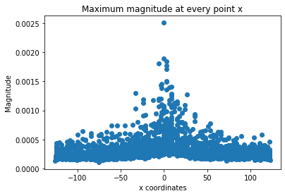

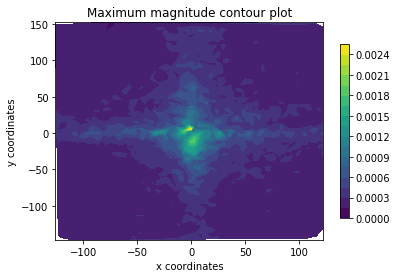

```python
## Feature 1: maximum absolute amplitude of each point vibration over time
max_amp_feature = np.max(np.abs(X_train), axis = 1) # axis=1 because we calculate it along the x axis


# Plot max amp feature over x coordinates
plt.figure()
plt.plot(xyz_train[:,0], max_amp_feature[:], 'o')
plt.title('Maximum magnitude at every point x')
plt.xlabel('x coordinates')
plt.ylabel('Magnitude')

# Plot max amp feature in xyz coordinates
plt.figure()
plt.tricontourf(xyz_train[:,0], xyz_train[:,1], max_amp_feature, 20)
plt.title('Maximum magnitude contour plot')
plt.xlabel('x coordinates')
plt.ylabel('y coordinates')
plt.colorbar(shrink = 0.8)
print('')
```

### Feature 2: RMS

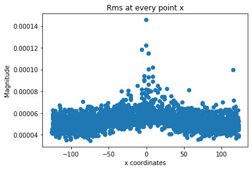

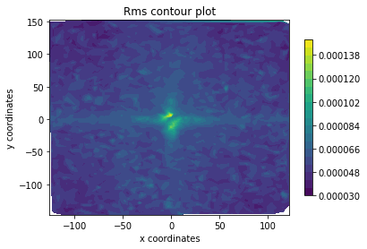

```python
## Feature 2: rms of each point vibration over time
rms_feature = rms = np.sqrt(np.mean(X_train**2, axis = 1)) # axis=1 because we calculate it along the x axis

# Plot rms feature over x coordinates
plt.figure()
plt.plot(xyz_train[:,0], rms_feature[:], 'o')
plt.title('Rms at every point x')
plt.xlabel('x coordinates')
plt.ylabel('Magnitude')

# Plot rms feature over xyz coordinates
plt.figure()
plt.tricontourf(xyz_train[:,0], xyz_train[:,1], rms_feature,20)
plt.title('Rms contour plot')
plt.xlabel('x coordinates')
plt.ylabel('y coordinates')
plt.colorbar(shrink = 0.8)
print('')
```

### Feature 3: Resonance Frequencies

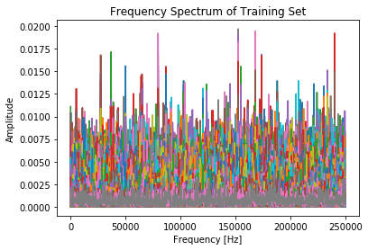

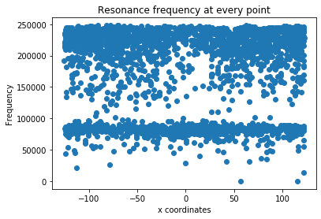

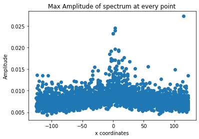

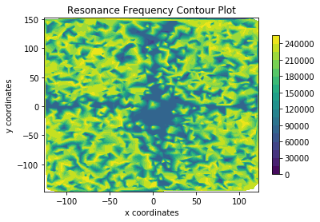

```python
## Feature 3 and 4: extract resonance frequncies of the signals and max amplitude at the resonances

# Import some library useful for fft
import scipy as sy
import scipy.fftpack as syfp
import pylab as pyl

# Initialize a fft matrix with same dimensions as the training set
X_train_shape = np.shape(X_train)
fft_X_train = np.zeros(X_train_shape)

# Fill each row of the FFT matrix with a Fast Fourier Transform of each signal in X_train
for iRow in range(X_train_shape[0]):
    fft_X_train[iRow] = syfp.fft(X_train[iRow, :])

# Sample Rate as provided in the challenge text (1 MHz)
SR = 1*10**6

# Length of the original signals
N = X_train_shape[1]

# Avoid aliasing by multiplying sampling frequency by 1/2 and form frequency vector
f = np.linspace(0, 0.5*SR, N)

# Plot frequency spectrum against amplitude for each point in the data set
plt.figure()
plt.ylabel("Amplitude")
plt.xlabel("Frequency [Hz]")
plt.plot(f[:N // 2], np.abs(fft_X_train)[:N // 2])
plt.title("Frequency Spectrum of Training Set")

# Assign the value of the fft to a temporary matrix
fft_temp = np.abs(fft_X_train[:,:N // 2])
fft_temp_shape = np.shape(fft_temp)

# Feature 3: max amplitude in the frequency spectrum for each point
fft_feature_amp = np.zeros(fft_temp_shape[0])

# Feature 4: index corresponding to the max amplitude, i.e. resonance frequency of every point
fft_feature_index = np.zeros(fft_temp_shape[0])

# For every point in the training set, calculate the frequency which has the maximum amplitude (fft_feature_index)
# and its amplitude (fft_feature_ampliude)
for i in range(fft_temp_shape[0]):
    fft_feature_amp[i] = np.max(np.abs(fft_temp[i,:]))
    fft_feature_index[i] = np.multiply(np.divide(np.argmax(np.abs(fft_temp[i,:])), fft_temp_shape[1]), SR/2)

# Plot the maximum frequency of vibration of every point
plt.figure()
plt.plot(xyz_train[:,0], fft_feature_index, 'o')
plt.title('Resonance frequency at every point')
plt.xlabel('x coordinates')
plt.ylabel('Frequency')
#plt.savefig('FrequencyDistribution.png')

# Plot the amplitude of each max frequency
plt.figure()
plt.plot(xyz_train[:,0], fft_feature_amp, 'o')
plt.title('Max Amplitude of spectrum at every point')
plt.xlabel('x coordinates')
plt.ylabel('Amplitude')

# Plot the maximum frequency of every point in a contour plot
plt.figure()
plt.tricontourf(xyz_train[:,0], xyz_train[:,1], fft_feature_index,20)
plt.title('Resonance Frequency Contour Plot')
plt.xlabel('x coordinates')
plt.ylabel('y coordinates')
plt.colorbar(shrink = 0.8)
print('')
```

Some considerations on these features.

- amplitude and rms: they show that the plate vibrates above all in the middle and along the middle axis
- frequency: the last plot shows two main frequencies of vibration, the lowest one. (~90 kHZ) is the first mode of vibration, which is expected to be in the middle of the plate according to plates theory. The second mode is usually higher (here ~240kHz) and is an antiphase vibration of two opposite parts of the plate.

We have now higlighted the behaviour of the points in the plate in terms of amplitude and frequency of vibration. When the new measured data will arrive in the evaluation set, we expect that if, for example, one of the new points is in the middle of the plate and resonates at a different frequency from the one highlighted here (~90 kHz) the point in that plate might be corrupted / cracked. This is a usual behaviour in structures: a crack in a plate, bridge or building will change its resonance frequencies and affect its vibration in general, including the maximum amplitude.

But we'll think about this later, now it's time to train a model that uses these features to describe the system under test.

## Step 3: Training

We choose an unsupervsed approach, to learn the density distribution of each feature. First, using a RBF Kernel we obtain the density of just one featureat a time (1D RBF Kernel Density Estimation).

Then we use a 2D RBF Kernel to obtain the Density Estimation of two features sets: eg max amplitude and rms, or resonance frequency and amplitude at that frequency.

### Kernel Density RBF Function

https://en.wikipedia.org/wiki/Radial_basis_function_kernel

```python
# Import necessary libraries
from scipy.spatial.distance import cdist

## Kernel Density RBF Function Definition
def kernel_density_rbf(x_train,x_test, h):
    r = cdist(x_train,x_test,'sqeuclidean')
    K = np.exp( -r/h )
    density = (1/h)*np.mean(K, axis=0)
    return density
```

### 1D Training of Max Amp

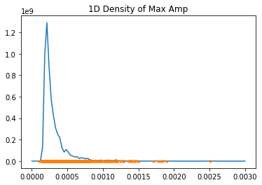

```python
## Define the training set using the max_amp_feature
x_train_maxamp = max_amp_feature[:]
x_train_maxamp = x_train_maxamp.reshape([len(x_train_maxamp),1])

# Define the test set
x_test_maxamp = np.linspace(0.0,.003,100).reshape([100,1])

# Hyperparameter
h_maxamp=0.0000000001

# Obtain the density of the test set
den_test_maxamp = kernel_density_rbf(x_train_maxamp,x_test_maxamp, h_maxamp)

# Plot the density
plt.figure()
plt.plot(x_test_maxamp,den_test_maxamp)
# plot the training points
plt.plot(x_train_maxamp,np.zeros([len(x_train_maxamp),]), '.')
plt.title('1D Density of Max Amp')
print('')
```

### 1D Training of RMS

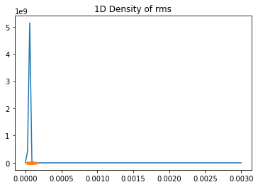

```python
# #Define the training set using the rms
x_train_rms = rms_feature[:]
x_train_rms = x_train_rms.reshape([len(x_train_rms),1])

# Define the test set
x_test_rms = np.linspace(0.0,.003,100).reshape([100,1])

# Hyperparameter
h_rms=0.0000000001

# Obtain the density of the test set
den_test_rms = kernel_density_rbf(x_train_rms,x_test_rms, h_rms)

# Plot the density
plt.figure()
plt.plot(x_test_rms,den_test_rms)
# plot the training points
plt.plot(x_train_rms,np.zeros([len(x_train_rms),]), '.')
plt.title('1D Density of rms')
print('')
```

### 1D Training of Resonance Frequencies

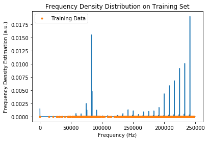

```python
# Define the training set using the resonances
x_train_fftind = fft_feature_index[:]
x_train_fftind = x_train_fftind.reshape([len(x_train_fftind),1])

# Define the test set
x_test_fftind = np.linspace(0,250000,10000).reshape([10000,1])

# Hyperparameter
h_fftind=0.5

# Obtain the density of the test set
den_test_fftind = kernel_density_rbf(x_train_fftind,x_test_fftind, h_fftind)

# Plot the density
plt.figure()
plt.plot(x_test_fftind,den_test_fftind)
plt.title('Frequency Density Distribution on Training Set')
plt.xlabel('Frequency (Hz)')
plt.ylabel('Frequency Density Estimation (a.u.)')

# plot the training points
plt.plot(x_train_fftind,np.zeros([len(x_train_fftind),]), '.', label = 'Training Data')
plt.legend(loc='upper left')
#plt.savefig('Frequency Density')
print('')
```

Nice! We can also calculate the exact value of the 2 maxima, just to know the two resonances.

```python
# Fundamental Frequency
resonance1 = np.argmax(den_test_fftind[0:5000])
resonance1 = resonance1 / 10000 * 250000
print('The fundamental frequency of the plate is at: ', int(resonance1), 'Hz')

# First Mode
resonance2 = np.argmax(den_test_fftind[0:10000])
resonance2 = resonance2 / 10000 * 250000
print('The second mode of the plate is at: ', int(resonance2), 'Hz')
```

```
The fundamental frequency of the plate is at:  83000 Hz
The second mode of the plate is at:  241675 Hz
```

### 1D Training on maximum amplitude of resonances

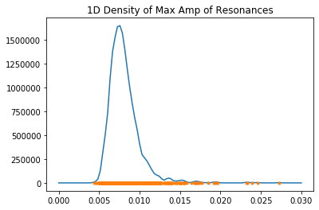

```python
## Define the training set using the resonance amplitude
x_train_fftamp = fft_feature_amp[:]
x_train_fftamp = x_train_fftamp.reshape([len(x_train_fftamp),1])

# Define the test set
x_test_fftamp = np.linspace(0.0,.03,100).reshape([100,1])

# Hyperparameter
h_fftamp=.0000001

# Obtain the density of the test set
den_test_fftamp = kernel_density_rbf(x_train_fftamp,x_test_fftamp, h_fftamp)

# Plot the density
plt.figure()
plt.plot(x_test_fftamp,den_test_fftamp)

# plot the training points
plt.plot(x_train_fftamp,np.zeros([len(x_train_fftamp),]), '.')
plt.title('1D Density of Max Amp of Resonances')
print('')
```

All right. Now it's time to train 2D Kernels with 2 features at the same time. Let's start with max amplitude and rms.

### 2D Training: Max Amplitude & RMS

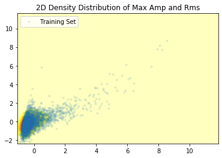

```python
## Training set for 2D max amp and rms
max_amp_feature = (max_amp_feature - np.mean(max_amp_feature))/np.std(max_amp_feature)
rms_feature = (rms_feature - np.mean(rms_feature))/np.std(rms_feature)
x_train_amp_rms = np.array([max_amp_feature,rms_feature])
x_train_amp_rms = np.transpose(x_train_amp_rms)

# Let's define the test matrix as a meshgrid with on one axis a vector from max_amp_feature min value to
# max_amp_feature max value, and on the other axis a vector from rms_feature min to max value.
xt1_amp_rms, xt2_amp_rms = np.meshgrid(np.linspace(np.min(max_amp_feature), (np.max(max_amp_feature)), 100),
                     np.linspace(np.min(rms_feature), np.max(rms_feature), 100))
x_test_amp_rms = np.c_[xt1_amp_rms.ravel(), xt2_amp_rms.ravel()]

# Hyperparameter for this features
h_amp_rms=0.1

# Train
den_test_amp_rms = kernel_density_rbf(x_train_amp_rms,x_test_amp_rms, h_amp_rms)

# Plot the density and the training points
den_levels_amp_rms = np.sqrt(np.std(den_test_amp_rms))*np.array([1,2,3])
#den_levels_amp_rms = 1.2*np.percentile(den_train_amp_rms, range(0,100,5))
plt.figure()
#plt.tricontourf(x_test_amp_rms[:,0], x_test_amp_rms[:,1], den_test_amp_rms, levels=den_levels_amp_rms, cmap = 'hot_r')
plt.tricontourf(x_test_amp_rms[:,0], x_test_amp_rms[:,1], den_test_amp_rms, cmap = 'hot_r')
#The above output is made so that the final image consists of 100x100 with an intensity value for each pixel
# plt.tripcolor(x_test[:,0], x_test[:,1], den_test, cmap = 'afmhot_r')
plt.plot(x_train_amp_rms[:,0],x_train_amp_rms[:,1], '.',alpha=0.1, label = 'Training Set')
plt.legend(loc='upper left')
plt.title('2D Density Distribution of Max Amp and Rms')
print('')
```

### 2D Training: Resonances & Max Amplitude at Resonance

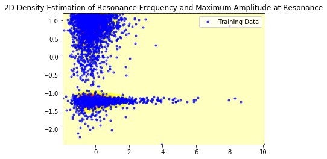

```python
# Training set for 2D resonances and max amp at resonances
fft_feature_amp = (fft_feature_amp - np.mean(fft_feature_amp))/np.std(fft_feature_amp)
fft_feature_index = (fft_feature_index - np.mean(fft_feature_index))/np.std(fft_feature_index)

x_train_fft_amp = np.array([fft_feature_amp,fft_feature_index])
x_train_fft_amp = np.transpose(x_train_fft_amp)

# Let's define the test matrix as a meshgrid with on one axis a vector from max_amp_feature min value to
# max_amp_feature max value, and on the other axis a vector from rms_feature min to max value.
xt1_fft_amp, xt2_fft_amp = np.meshgrid(np.linspace(np.min(fft_feature_amp), (np.max(fft_feature_amp)), 100),
                     np.linspace(np.min(fft_feature_index), np.max(fft_feature_index), 100))
x_test_fft_amp = np.c_[xt1_fft_amp.ravel(), xt2_fft_amp.ravel()]

# Hyperparameter for this features
h_fft_amp=0.03

# Train
den_test_fft_amp = kernel_density_rbf(x_train_fft_amp,x_test_fft_amp, h_fft_amp)
den_train_fft_amp = kernel_density_rbf(x_train_fft_amp,x_train_fft_amp, h_fft_amp)

# Plot the density and the training points
den_levels_fft_amp = np.sqrt(np.std(den_train_fft_amp))*np.array([1,2,3])
#den_levels_fft_amp = 1.2*np.percentile(den_train_fft_amp, range(0,100,5))
plt.figure()
#plt.tricontourf(x_test_fft_amp[:,0], x_test_fft_amp[:,1], den_test_fft_amp, levels=den_levels_fft_amp, cmap = 'hot_r')
plt.tricontourf(x_test_fft_amp[:,0], x_test_fft_amp[:,1], den_test_fft_amp, cmap = 'hot_r')
plt.title('2D Density Estimation of Resonance Frequency and Maximum Amplitude at Resonance')
#The above output is made so that the final image consists of 100x100 with an intensity value for each pixel
# plt.tripcolor(x_test[:,0], x_test[:,1], den_test, cmap = 'afmhot_r')
plt.plot(x_train_fft_amp[:,0],x_train_fft_amp[:,1], '.b',alpha=0.7, label = 'Training Data')
plt.legend(loc='upper right')
#plt.savefig('2DFreqDensity.png')
```

Wow! Now we can see the two density distributions for the main resonances. This is my favourite plot up to now.

Since we have now trained a lot of different models we can enter the next phase of the challenge. Even though one model would have been enough, I wanted to apply different techniques learned during the week and also be ready for the last phase, as one model could be better than the others at classifying abnormal points - always better to be ready! For the validation part though, I just used the 2D densities, as they better identify the system and I didn't have infinite time.

## Step 4: Validation

At this point of the challenge - kind of ~2 hours in - we received the validation set. This is a new bunch of data, supposedly good data, that we can use to validate our training. Let's import it and have a look at it first.

### Loading and visualizing the validation set

```python
## Load validation data
data_validation = loadmat('ML_challenge_wave_data_validation.mat')

X_validation = data_validation['wave'] # nxd matrix, n: num of ultrasonic pulses collected, d: num of data points in each wave
xyz_validation = data_validation['xyz'] # nx3 matrix, n: num of observations along the rows and , x,y,z coordinates along the columns
```

```
The matrix X has dimensions:  (2726, 2048)
The matrix xyz has dimensions:  (2726, 3)
```

[figure not shown]

```python
## Let's look at the data
print('The matrix X has dimensions: ',np.shape(X_validation))
print('The matrix xyz has dimensions: ',np.shape(xyz_validation))

# How the points are placed in the plate
plt.figure()
plt.plot(xyz_validation[:,0], X_validtion[:,1], 'o')
plt.title('Validation Dataset: Points Positions in the Plate')
plt.xlabel('x coordinates')
plt.ylabel('y coordinates')

print('')
```

### Features extraction

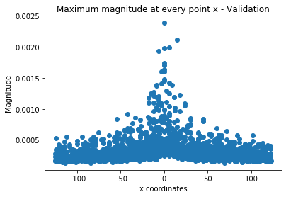

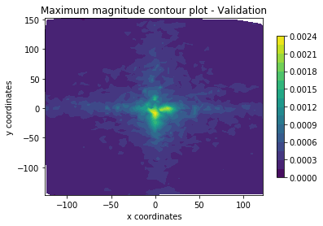

```python
## Feature 1: maximum absolute amplitude of each point vibration over time
max_amp_feature_val = np.max(np.abs(X_validation), axis = 1) # axis=1 because we calculate it along the x axis

## Plot features from your data in xyz coordinates

plt.figure()
plt.plot(xyz_validation[:,0], max_amp_feature_val[:], 'o')
plt.title('Maximum magnitude at every point x - Validation')
plt.xlabel('x coordinates')
plt.ylabel('Magnitude')

plt.figure()
plt.tricontourf(xyz_validation[:,0], xyz_validation[:,1], max_amp_feature_val, 20)
plt.title('Maximum magnitude contour plot - Validation')
plt.xlabel('x coordinates')
plt.ylabel('y coordinates')
plt.colorbar(shrink = 0.8)
```

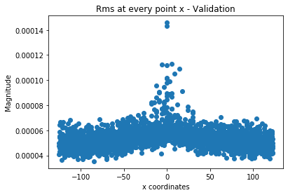

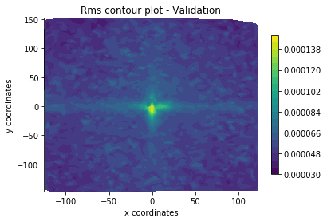

```python
## Feature 2: rms of each point vibration over time
rms_feature_val = np.sqrt(np.mean(X_validation**2, axis = 1)) # axis=1 because we calculate it along the x axis

## Plot features from your data in xyz coordinates

plt.figure()
plt.plot(xyz_validation[:,0], rms_feature_val[:], 'o')
plt.title('Rms at every point x - Validation')
plt.xlabel('x coordinates')
plt.ylabel('Magnitude')

plt.figure()
plt.tricontourf(xyz_validation[:,0], xyz_validation[:,1], rms_feature_val,20)
plt.title('Rms contour plot - Validation')
plt.xlabel('x coordinates')
plt.ylabel('y coordinates')
plt.colorbar(shrink = 0.8)
```

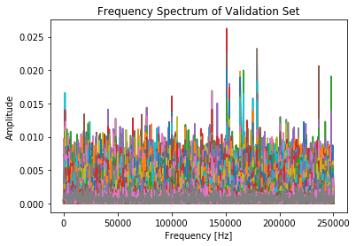

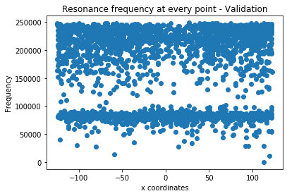

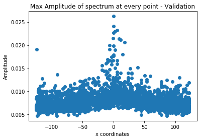

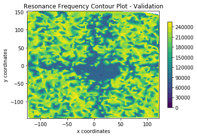

```python
## Feature 3 and 4: extract resonance frequncies of the signals and max amplitude at the resonances

# Initialize a fft matrix with same dimensions as the training set
X_val_shape = np.shape(X_validation)
fft_X_val = np.zeros(X_val_shape)

# Fill each row of the FFT matrix with a Fast Fourier Transform of each signal in X_train
for iRow in range(X_val_shape[0]):
    fft_X_val[iRow] = syfp.fft(X_validation[iRow, :])

# Sample Rate as provided in the challenge text (1 MHz)
SR_val = 1*10**6

# Length of the original signals
N_val = X_val_shape[1]

# Avoid aliasing by multiplying sampling frequency by 1/2 and form frequency vector
f_val = np.linspace(0, 0.5*SR_val, N_val)

# Plot frequency spectrum against amplitude for each point in the data set
plt.figure()
plt.ylabel("Amplitude")
plt.xlabel("Frequency [Hz]")
plt.plot(f_val[:N // 2], np.abs(fft_X_val)[:N // 2])
plt.title("Frequency Spectrum of Validation Set")

# Assign the value of the fft to a temporary matrix
fft_temp_val = np.abs(fft_X_val[:,:N // 2])
fft_temp_shape_val = np.shape(fft_temp_val)

# Feature 3: max amplitude in the frequency spectrum for each point
fft_feature_amp_val = np.zeros(fft_temp_shape_val[0])

# Feature 4: index corresponding to the max amplitude, i.e. resonance frequency of every point
fft_feature_index_val = np.zeros(fft_temp_shape_val[0])

# For every point in the training set, calculate the frequency which has the maximum amplitude (fft_feature_index)
# and its amplitude (fft_feature_ampliude)
for i in range(fft_temp_shape_val[0]):
    fft_feature_amp_val[i] = np.max(np.abs(fft_temp_val[i,:]))
    fft_feature_index_val[i] = np.multiply(np.divide(np.argmax(np.abs(fft_temp_val[i,:])), fft_temp_shape_val[1]), SR_val/2)

# Plot the maximum frequency of vibration of every point
plt.figure()
plt.plot(xyz_validation[:,0], fft_feature_index_val, 'o')
plt.title('Resonance frequency at every point - Validation')
plt.xlabel('x coordinates')
plt.ylabel('Frequency')

# Plot the amplitude of each max frequency
plt.figure()
plt.plot(xyz_validation[:,0], fft_feature_amp_val, 'o')
plt.title('Max Amplitude of spectrum at every point - Validation')
plt.xlabel('x coordinates')
plt.ylabel('Amplitude')

# Plot the maximum frequency of every point in a contour plot
plt.figure()
plt.tricontourf(xyz_validation[:,0], xyz_validation[:,1], fft_feature_index_val,20)
plt.title('Resonance Frequency Contour Plot - Validation')
plt.xlabel('x coordinates')
plt.ylabel('y coordinates')
plt.colorbar(shrink = 0.8)
print('')
```

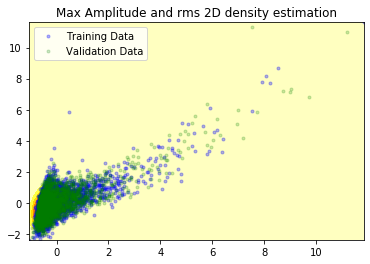

```python
# Features 1 and 2 - Validation

max_amp_feature_val = (max_amp_feature_val - np.mean(max_amp_feature_val))/np.std(max_amp_feature_val)
rms_feature_val = (rms_feature_val - np.mean(rms_feature_val))/np.std(rms_feature_val)

x_val_rms_amp = np.array([max_amp_feature_val,rms_feature_val])
x_val_rms_amp = np.transpose(x_val_rms_amp)

# Plot the density and the training points
den_levels_amp_rms = np.sqrt(np.std(den_train_amp_rms))*np.array([1,2,3])
#den_levels_amp_rms = 1.2*np.percentile(den_train_amp_rms, range(0,100,5))
plt.figure()
#plt.tricontourf(x_test_amp_rms[:,0], x_test_amp_rms[:,1], den_test_amp_rms, levels=den_levels_amp_rms, cmap = 'hot_r')
plt.tricontourf(x_test_amp_rms[:,0], x_test_amp_rms[:,1], den_test_amp_rms, cmap = 'hot_r')
#The above output is made so that the final image consists of 100x100 with an intensity value for each pixel
# plt.tripcolor(x_test[:,0], x_test[:,1], den_test, cmap = 'afmhot_r')

plt.plot(x_train_amp_rms[:,0],x_train_amp_rms[:,1], '.b',alpha=0.3, label = 'Training Data')
plt.plot(x_val_rms_amp[:,0],x_val_rms_amp[:,1], '.g',alpha=0.2, label = 'Validation Data')
plt.legend(loc = 'upper left')
plt.title('Max Amplitude and rms 2D density estimation')
print('')
```

```
(2726, 2)
(2726, 2)
```

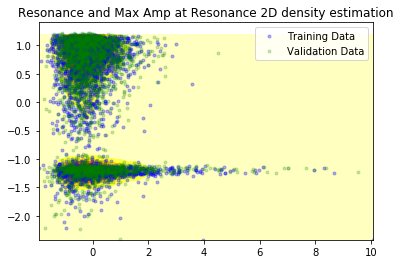

```python
# Features 3 and 4

fft_feature_amp_val = (fft_feature_amp_val - np.mean(fft_feature_amp_val))/np.std(fft_feature_amp_val)
fft_feature_index_val = (fft_feature_index_val - np.mean(fft_feature_index_val))/np.std(fft_feature_index_val)



x_val_fft_amp = np.array([fft_feature_amp_val,fft_feature_index_val])
x_val_fft_amp = np.transpose(x_val_fft_amp)



print(np.shape(x_val_fft_amp))
print(np.shape(x_train_fft_amp))

# Plot the density and the training points
den_levels_fft_amp = np.sqrt(np.std(den_train_fft_amp))*np.array([1,2,3])
#den_levels_fft_amp = 1.2*np.percentile(den_train_fft_amp, range(0,100,5))
plt.figure()
#plt.tricontourf(x_test_fft_amp[:,0], x_test_fft_amp[:,1], den_test_fft_amp, levels=den_levels_fft_amp, cmap = 'hot_r')
plt.tricontourf(x_test_fft_amp[:,0], x_test_fft_amp[:,1], den_test_fft_amp, cmap = 'hot_r')
#The above output is made so that the final image consists of 100x100 with an intensity value for each pixel
# plt.tripcolor(x_test[:,0], x_test[:,1], den_test, cmap = 'afmhot_r')

plt.plot(x_train_fft_amp[:,0],x_train_fft_amp[:,1], '.b',alpha=0.3, label = 'Training Data')
plt.plot(x_val_fft_amp[:,0],x_val_fft_amp[:,1], '.g',alpha=0.2, label = 'Validation Data')
plt.legend(loc = 'upper right')
plt.title('Resonance and Max Amp at Resonance 2D density estimation')
print('')
```

The new data fit well in our model, so we are ready for the evaluation step. In this last operative step, a new set of data is received. It could have been collected time after the first measurements, so if it does not fit into the model it could raise an alarm on the changed state of the plate. Of course it could also raise an alarm on our model...altough this validation step gave us some confidence ;)